# Simulation experiment (8)

# Design of the experiment

This experiment is designed based on actual soil data from EJP Soil. Below we show ECEC (mmol/kg) as measured by the central Eurofins laboratory (using ISO-23470) vs. the measurements from national labs (where available). Belgium-Wallonia and France used the same method as Eurofins, while other countries used different methods and require a transfer function.

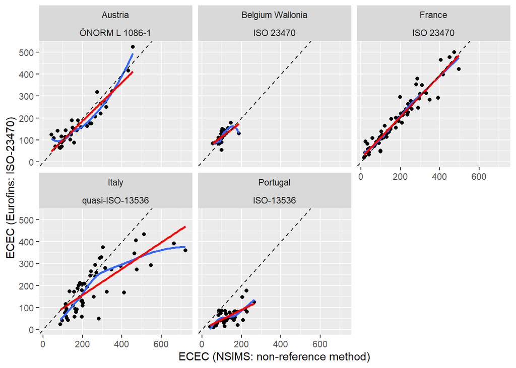

**Note**

Is the small range of data in Wallonia and Portugal (compared to other countries) expected?

## Italy & Portugal

Let’s take Italy and Portugal as an example (TF from ISO-13536 to ISO-23470). We ignore the variation within ISO-13536 for the moment and combine both countries, just for illustrative purposes. Below we show the data and some summary statistics of the ECEC with the NSIMS method. Just from eyeballing we can see that the prediction intervals for the transfer function will be too large for practical use (I think?). Perhaps better with multiple predictors?

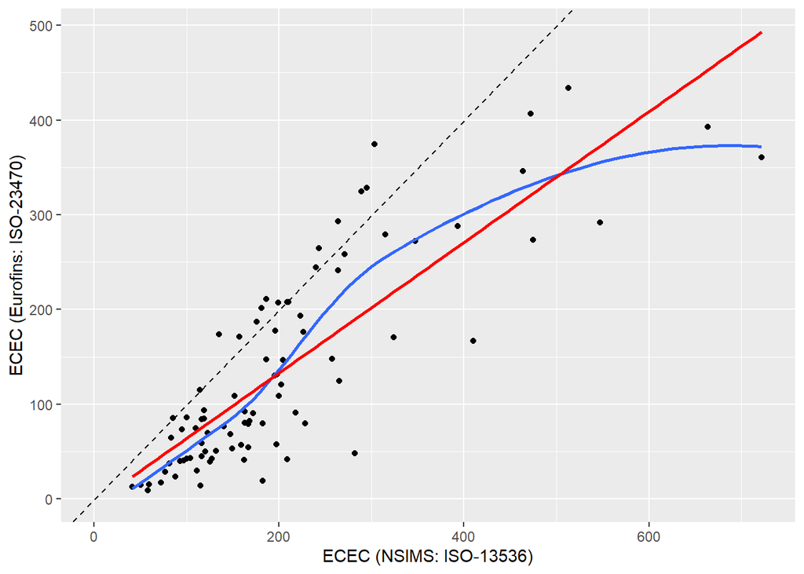

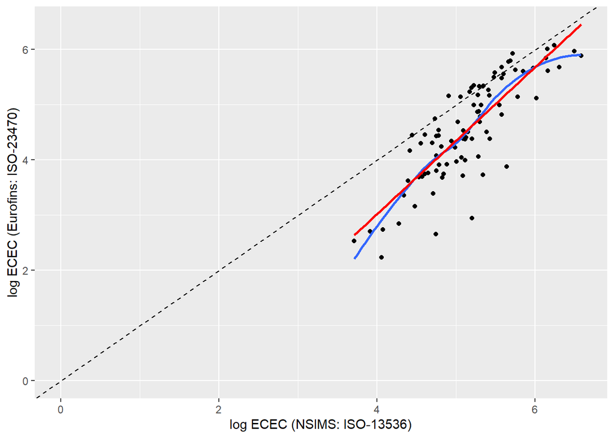

```
# A tibble: 1 × 3
  mean_ecec_nsims sd_ecec_nsims cv_ecec_nsims
            <dbl>         <dbl>         <dbl>
1            204.          130.         0.637
```

The idea is to design a simulation experiment as follows. We fit the Gamma EIV-model with unknown $CV$ of the measurement error to these data. The purpose of this model is to use it to simulate new data-sets that are similar to the ISO-13536 ECEC data but whose properties we know exactly so we can calculate bias and coverage metrics.

We make the following modifications to the model because the values of ECEC are different than those in the simulations before.

- we use a non-centered prior on $\beta_0$

```r
library(cmdstanr) |> suppressPackageStartupMessages()

mod <- cmdstan_model(here::here("source/stan-ECEC/gammareg_eiv_realECEC.stan"),
                     compile = TRUE)

stan_list <- list(
  N     = nrow(ecec_13536),
  x_obs = as.numeric(ecec_13536$ecec_nsims),
  y_obs = as.numeric(ecec_13536$ecec_eurofins)
)

fit <- mod$sample(data = stan_list, show_messages = F, show_exceptions = F,
                  adapt_delta = 0.99, max_treedepth = 12)

# summary statistics
fit$summary(
  variables = c("mu_x","cv_x","shape_mex","beta0","beta0c","beta1","shape")
)
```

```
# A tibble: 7 × 10
  variable     mean  median      sd     mad      q5     q95  rhat ess_bulk
  <chr>       <dbl>   <dbl>   <dbl>   <dbl>   <dbl>   <dbl> <dbl>    <dbl>
1 mu_x      203.    203.    10.4    10.5    186.    220.     1.00    3263.
2 cv_x        0.509   0.508  0.0464  0.0464   0.435   0.588  1.00    1408.
3 shape_mex  18.4    16.5    7.72    5.99     9.94   33.5    1.01     456.
4 beta0      -3.51   -3.47   0.821   0.814   -4.92   -2.22   1.01     558.
5 beta0c      4.59    4.59   0.0687  0.0665   4.47    4.70   1.00     793.
6 beta1       1.57    1.56   0.154   0.152    1.33    1.84   1.01     581.
7 shape       7.26    6.52   3.15    2.00     4.20   12.8    1.01     449.
# ℹ 1 more variable: ess_tail <dbl>
```

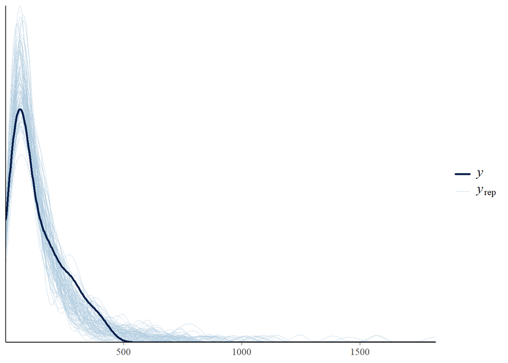

```r
# goodness-of-fit
y_rep <- fit$draws("y_rep", format = "matrix")
bayesplot::ppc_dens_overlay(y = stan_list$y_obs, yrep = y_rep[1:100, ])
```

We now have a model that we can use to create new simulated datasets that mimic the original one. We restrict to the 90% HDI of the posterior to draw from to avoid unrealistic cases. The simulated dataset below resembles more or less to the original one but now we “know” the true and observed values.

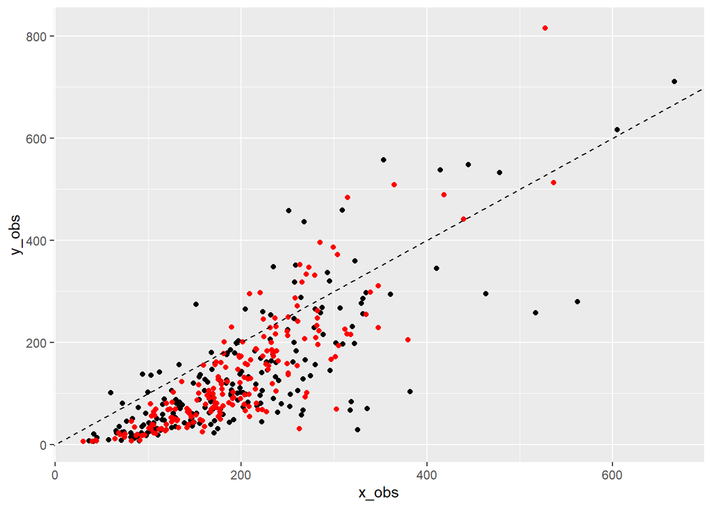

```r
draws_params <- fit$draws(
  variables = c("mu_x","cv_x","shape_x","shape_mex",
                "beta0","beta0","beta1","shape"),
  format = "draws_df"
) %>%
  mutate(
    cv_mex          = 1/sqrt(shape_mex),
    ratio_cvmex_cvx = cv_mex /cv_x
  )

hdi_params <- bayestestR::hdi(draws_params, .90)

draws_params_hdi <- draws_params %>%
  filter(
    between(mu_x, hdi_params[1,3], hdi_params[1,4]),
    between(cv_x, hdi_params[2,3], hdi_params[2,4]),
    between(shape_mex, hdi_params[4,3], hdi_params[4,4]),
    between(beta0, hdi_params[5,3], hdi_params[5,4]),
    between(beta1, hdi_params[6,3], hdi_params[6,4]),
    between(shape, hdi_params[7,3], hdi_params[7,4])
  )

source(here::here("source/R/simulate-data-gamma.R"))

# take the parameter values from a random draw to create new data
idx <- sample(1:nrow(draws_params_hdi), 1)
data_ecec_sim <- sim_data_gamma(
  N    = 200,          # not a model parameter, we choose this
  mu_x = draws_params_hdi$mu_x[idx],
  cv_x = draws_params_hdi$cv_x[idx],
  cv_y = 1/sqrt(draws_params_hdi$shape[idx]),
  alpha = draws_params_hdi$beta0[idx],
  beta  = draws_params_hdi$beta1[idx],
  ratio_cvmex_cvx = draws_params_hdi$ratio_cvmex_cvx[idx],
  ratio_mey_mex = 1,   # not a model parameter, we choose this
  corr_error    = 0.5  # not a model parameter, we choose this
)

data_ecec_sim_cal <- data.frame(
  x_obs = data_ecec_sim$x_obs,
  y_obs = data_ecec_sim$y_obs,
  x_true = data_ecec_sim$x_true,
  y_true = data_ecec_sim$y_true
)

ggplot(data_ecec_sim_cal) +
  geom_point(aes(x_obs, y_obs)) +
  geom_point(aes(x_true, y_true), color = "red") +
  geom_abline(slope = 1, intercept = 0, lty = 2)
```

```r
save(draws_params_hdi, file = here::here("data/draws_params_hdi_ECEC.rda"))
```

The simulation experiment can then proceed as follows: for each replicate, we take a draw from the posterior, plug the values in `sim_data_gamma()` to simulate training and calibration data, use the same models as before to fit a TF in the training data, predict the values in the calibration data and evaluate the predictions. The results are summarized below:

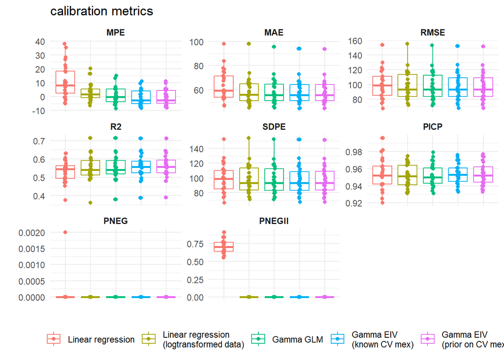

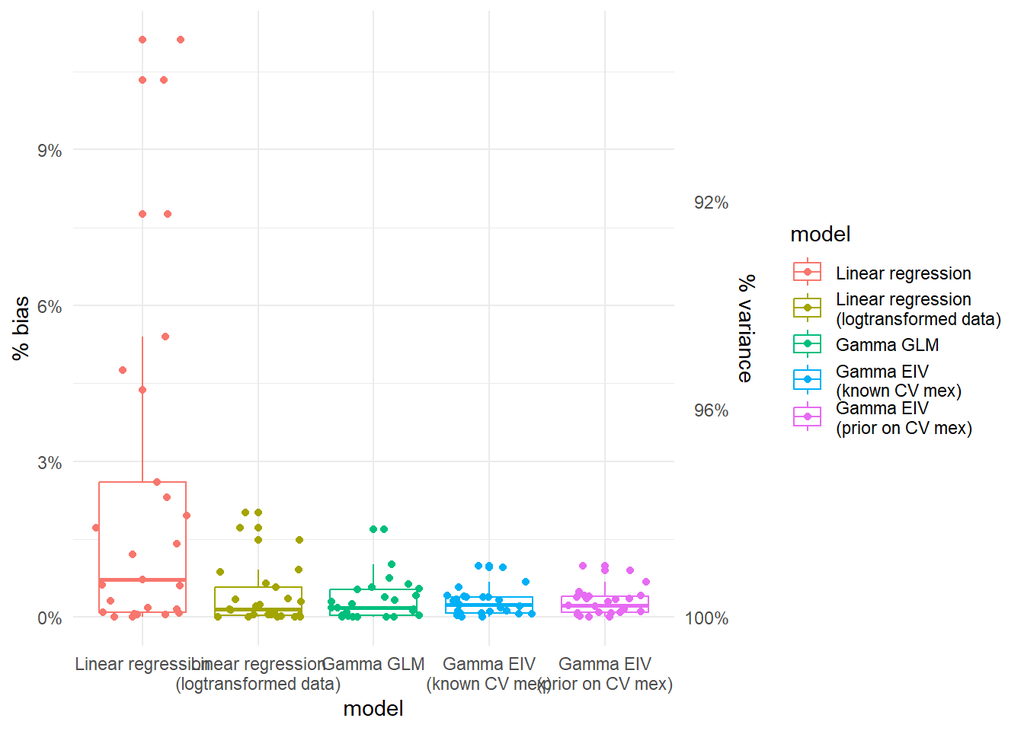

Figure 1: Results of the simulation experiment: %bias and %variance

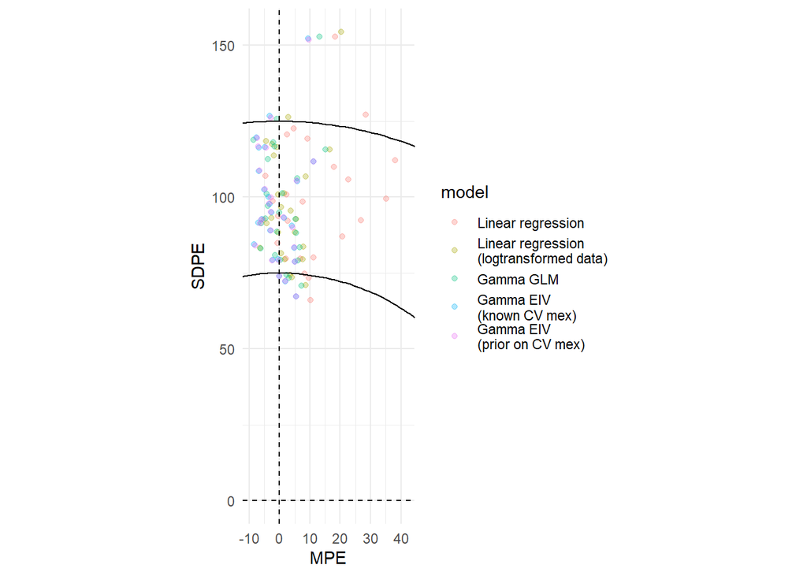

Figure 2: Results of the simulation experiment: MPE vs. SDPE. All points on the circles have the same RMSE.

### Model diagnostics: MCMC $\hat{R}$

The following figures display the $\hat{R}$ statistic of the MCMC for each of the model parameters. The red dashed lines are at 1.00 and 1.01. The boxplots are aggregated across scenario’s. The Gamma EIV-model with unknown $CV$ of the measurement error suffers from poor mixing.

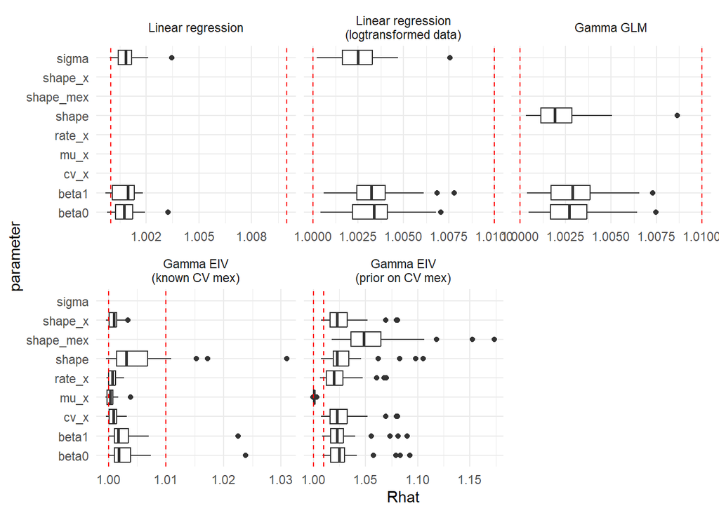